# Convolutional Neural Networks

## Project: Write an Algorithm for a Dog Identification App

In this notebook, some template code has already been provided for you, and you will need to implement additional functionality to successfully complete this project. You will not need to modify the included code beyond what is requested. Sections that begin with **'(IMPLEMENTATION)'** in the header indicate that the following block of code will require additional functionality which you must provide. Instructions will be provided for each section, and the specifics of the implementation are marked in the code block with a 'TODO' statement. Please be sure to read the instructions carefully!

> **Note**: Once you have completed all of the code implementations, you need to finalize your work by exporting the Jupyter Notebook as an HTML document. Before exporting the notebook to html, all of the code cells need to have been run so that reviewers can see the final implementation and output. You can then export the notebook by using the menu above and navigating to **File -> Download as -> HTML (.html)**. Include the finished document along with this notebook as your submission.

In addition to implementing code, there will be questions that you must answer which relate to the project and your implementation. Each section where you will answer a question is preceded by a **'Question X'** header. Carefully read each question and provide thorough answers in the following text boxes that begin with **'Answer:'**. Your project submission will be evaluated based on your answers to each of the questions and the implementation you provide.

> **Note:** Code and Markdown cells can be executed using the **Shift + Enter** keyboard shortcut. Markdown cells can be edited by double-clicking the cell to enter edit mode.

The rubric contains *optional* "Stand Out Suggestions" for enhancing the project beyond the minimum requirements. If you decide to pursue the "Stand Out Suggestions", you should include the code in this Jupyter notebook.

### Why We're Here

In this notebook, you will make the first steps towards developing an algorithm that could be used as part of a mobile or web app. At the end of this project, your code will accept any user-supplied image as input. If a dog is detected in the image, it will provide an estimate of the dog's breed. If a human is detected, it will provide an estimate of the dog breed that is most resembling. The image below displays potential sample output of your finished project (... but we expect that each student's algorithm will behave differently!).

[figure not shown]

In this real-world setting, you will need to piece together a series of models to perform different tasks; for instance, the algorithm that detects humans in an image will be different from the CNN that infers dog breed. There are many points of possible failure, and no perfect algorithm exists. Your imperfect solution will nonetheless create a fun user experience!

### The Road Ahead

We break the notebook into separate steps. Feel free to use the links below to navigate the notebook.

- Step 0: Import Datasets
- Step 1: Detect Humans
- Step 2: Detect Dogs
- Step 3: Create a CNN to Classify Dog Breeds (from Scratch)
- Step 4: Create a CNN to Classify Dog Breeds (using Transfer Learning)
- Step 5: Write your Algorithm
- Step 6: Test Your Algorithm

## Step 0: Import Datasets

Make sure that you've downloaded the required human and dog datasets:

- Download the [dog dataset](https://s3-us-west-1.amazonaws.com/udacity-aind/dog-project/dogImages.zip). Unzip the folder and place it in this project's home directory, at the location `/dogImages`.
- Download the [human dataset](https://s3-us-west-1.amazonaws.com/udacity-aind/dog-project/lfw.zip). Unzip the folder and place it in the home directory, at location `/lfw`.

*Note: If you are using a Windows machine, you are encouraged to use [7zip](http://www.7-zip.org/) to extract the folder.*

In the code cell below, we save the file paths for both the human (LFW) dataset and dog dataset in the numpy arrays `human_files` and `dog_files`.

```python
import numpy as np
from glob import glob
from tqdm import tqdm

lfw = 'lfw/*/*.jpg'
dogImages = 'dogImages/*/*/*.jpg'

##### Change the next variable to False if you are not using Google Colab
using_colab = False
#########################################################################

if using_colab:
    from google.colab import drive
    drive.mount('/content/drive', force_remount=True)
    drive_path = '/content/drive/My Drive/Colab Notebooks/dog_project/'
    lfw = drive_path + lfw
    dogImages = drive_path + dogImages

# load filenames for human and dog images
human_files = np.array(glob(lfw))
dog_files = np.array(glob(dogImages))

# print number of images in each dataset
print('There are %d total human images.' % len(human_files))
print('There are %d total dog images.' % len(dog_files))
```

```
There are 13235 total human images.
There are 8351 total dog images.
```

## Step 1: Detect Humans

In this section, we use OpenCV's implementation of [Haar feature-based cascade classifiers](http://docs.opencv.org/trunk/d7/d8b/tutorial_py_face_detection.html) to detect human faces in images.

OpenCV provides many pre-trained face detectors, stored as XML files on [github](https://github.com/opencv/opencv/tree/master/data/haarcascades). We have downloaded one of these detectors and stored it in the `haarcascades` directory. In the next code cell, we demonstrate how to use this detector to find human faces in a sample image.

```
Number of faces detected: 1
```

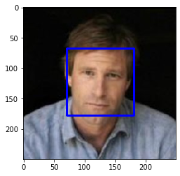

```python
import cv2
import matplotlib.pyplot as plt
%matplotlib inline

haar_path = 'haarcascades/haarcascade_frontalface_alt.xml'

if using_colab:
    haar_path = drive_path + haar_path

# extract pre-trained face detector
face_cascade = cv2.CascadeClassifier(haar_path)

# load color (BGR) image
img = cv2.imread(human_files[0])
# convert BGR image to grayscale
gray = cv2.cvtColor(img, cv2.COLOR_BGR2GRAY)

# find faces in image
faces = face_cascade.detectMultiScale(gray)

# print number of faces detected in the image
print('Number of faces detected:', len(faces))

# get bounding box for each detected face
for (x,y,w,h) in faces:
    # add bounding box to color image
    cv2.rectangle(img,(x,y),(x+w,y+h),(255,0,0),2)

# convert BGR image to RGB for plotting
cv_rgb = cv2.cvtColor(img, cv2.COLOR_BGR2RGB)

# display the image, along with bounding box
plt.imshow(cv_rgb)
plt.show()
```

Before using any of the face detectors, it is standard procedure to convert the images to grayscale. The `detectMultiScale` function executes the classifier stored in `face_cascade` and takes the grayscale image as a parameter.

In the above code, `faces` is a numpy array of detected faces, where each row corresponds to a detected face. Each detected face is a 1D array with four entries that specifies the bounding box of the detected face. The first two entries in the array (extracted in the above code as `x` and `y`) specify the horizontal and vertical positions of the top left corner of the bounding box. The last two entries in the array (extracted here as `w` and `h`) specify the width and height of the box.

### Write a Human Face Detector

We can use this procedure to write a function that returns `True` if a human face is detected in an image and `False` otherwise. This function, aptly named `face_detector`, takes a string-valued file path to an image as input and appears in the code block below.

```python
# returns "True" if face is detected in image stored at img_path
def face_detector(img_path):
    img = cv2.imread(img_path)
    gray = cv2.cvtColor(img, cv2.COLOR_BGR2GRAY)
    faces = face_cascade.detectMultiScale(gray)
    return len(faces) > 0
```

### (IMPLEMENTATION) Assess the Human Face Detector

**Question 1:** Use the code cell below to test the performance of the `face_detector` function.

- What percentage of the first 100 images in `human_files` have a detected human face?
- What percentage of the first 100 images in `dog_files` have a detected human face?

Ideally, we would like 100% of human images with a detected face and 0% of dog images with a detected face. You will see that our algorithm falls short of this goal, but still gives acceptable performance. We extract the file paths for the first 100 images from each of the datasets and store them in the numpy arrays `human_files_short` and `dog_files_short`.

**Answer:** (You can print out your results and/or write your percentages in this cell)

- 96% of the images in `human_files_short` have a detected face.
- 18% of the images in `dog_files_short` have a detected face.

```python
human_files_short = human_files[:100]
dog_files_short = dog_files[:100]

# Human files
detected_faces = 0
for file in tqdm(human_files_short):
    number_faces = face_detector(file)

    if number_faces > 0:
        detected_faces += 1

print(f'Human files: {detected_faces/100} -> should be 1.0')

# Dog files
detected_faces = 0
for file in tqdm(dog_files_short):
    number_faces = face_detector(file)

    if number_faces > 0:
        detected_faces += 1

print(f'Dog files: {detected_faces/100} -> should be 0.0')
```

```
Human files: 0.96 -> should be 1.0
```

```
Dog files: 0.18 -> should be 0.0
```

We suggest the face detector from OpenCV as a potential way to detect human images in your algorithm, but you are free to explore other approaches, especially approaches that make use of deep learning :). Please use the code cell below to design and test your own face detection algorithm. If you decide to pursue this *optional* task, report performance on `human_files_short` and `dog_files_short`.

```python
haar_path2 = 'haarcascades/haarcascade_frontalface_alt2.xml'

if using_colab:
    haar_path2 = drive_path + haar_path2

# extract pre-trained face detector
face_cascade2 = cv2.CascadeClassifier(haar_path2)

# returns "True" if face is detected in image stored at img_path
def face_detector2(img_path):
    img = cv2.imread(img_path)
    gray = cv2.cvtColor(img, cv2.COLOR_BGR2GRAY)
    faces = face_cascade2.detectMultiScale(gray)
    return len(faces) > 0

# Human files
detected_faces = 0
for file in tqdm(human_files_short):
    number_faces = face_detector2(file)

    if number_faces > 0:
        detected_faces += 1

print(f'Human files: {detected_faces/100} -> should be 1.0')

# Dog files
detected_faces = 0
for file in tqdm(dog_files_short):
    number_faces = face_detector2(file)

    if number_faces > 0:
        detected_faces += 1

print(f'Dog files: {detected_faces/100} -> should be 0.0')
```

```
Human files: 0.97 -> should be 1.0
```

```
Dog files: 0.22 -> should be 0.0
```

## Step 2: Detect Dogs

In this section, we use a [pre-trained model](http://pytorch.org/docs/master/torchvision/models.html) to detect dogs in images.

### Obtain Pre-trained VGG-16 Model

The code cell below downloads the VGG-16 model, along with weights that have been trained on [ImageNet](http://www.image-net.org/), a very large, very popular dataset used for image classification and other vision tasks. ImageNet contains over 10 million URLs, each linking to an image containing an object from one of [1000 categories](https://gist.github.com/yrevar/942d3a0ac09ec9e5eb3a).

```python
import torch
import torchvision.models as models

# define VGG16 model
VGG16 = models.vgg16(pretrained=True)

# check if CUDA is available
use_cuda = torch.cuda.is_available()

# move model to GPU if CUDA is available
if use_cuda:
    print('===== Using Cuda =====')
    print(f'GPU in use: {torch.cuda.get_device_name(0)}')
    VGG16 = VGG16.cuda()

print(VGG16)
```

```
===== Using Cuda =====
GPU in use: GeForce GTX 960M
VGG(
  (features): Sequential(
    (0): Conv2d(3, 64, kernel_size=(3, 3), stride=(1, 1), padding=(1, 1))
    (1): ReLU(inplace=True)
    (2): Conv2d(64, 64, kernel_size=(3, 3), stride=(1, 1), padding=(1, 1))
    (3): ReLU(inplace=True)
    (4): MaxPool2d(kernel_size=2, stride=2, padding=0, dilation=1, ceil_mode=False)
    (5): Conv2d(64, 128, kernel_size=(3, 3), stride=(1, 1), padding=(1, 1))
    (6): ReLU(inplace=True)
    (7): Conv2d(128, 128, kernel_size=(3, 3), stride=(1, 1), padding=(1, 1))
    (8): ReLU(inplace=True)
    (9): MaxPool2d(kernel_size=2, stride=2, padding=0, dilation=1, ceil_mode=False)
    (10): Conv2d(128, 256, kernel_size=(3, 3), stride=(1, 1), padding=(1, 1))
    (11): ReLU(inplace=True)
    (12): Conv2d(256, 256, kernel_size=(3, 3), stride=(1, 1), padding=(1, 1))
    (13): ReLU(inplace=True)
    (14): Conv2d(256, 256, kernel_size=(3, 3), stride=(1, 1), padding=(1, 1))
    (15): ReLU(inplace=True)
    (16): MaxPool2d(kernel_size=2, stride=2, padding=0, dilation=1, ceil_mode=False)
    (17): Conv2d(256, 512, kernel_size=(3, 3), stride=(1, 1), padding=(1, 1))
    (18): ReLU(inplace=True)
    (19): Conv2d(512, 512, kernel_size=(3, 3), stride=(1, 1), padding=(1, 1))
    (20): ReLU(inplace=True)
    (21): Conv2d(512, 512, kernel_size=(3, 3), stride=(1, 1), padding=(1, 1))
    (22): ReLU(inplace=True)
    (23): MaxPool2d(kernel_size=2, stride=2, padding=0, dilation=1, ceil_mode=False)
    (24): Conv2d(512, 512, kernel_size=(3, 3), stride=(1, 1), padding=(1, 1))
    (25): ReLU(inplace=True)
    (26): Conv2d(512, 512, kernel_size=(3, 3), stride=(1, 1), padding=(1, 1))
    (27): ReLU(inplace=True)
    (28): Conv2d(512, 512, kernel_size=(3, 3), stride=(1, 1), padding=(1, 1))
    (29): ReLU(inplace=True)
    (30): MaxPool2d(kernel_size=2, stride=2, padding=0, dilation=1, ceil_mode=False)
  )
  (avgpool): AdaptiveAvgPool2d(output_size=(7, 7))
  (classifier): Sequential(
    (0): Linear(in_features=25088, out_features=4096, bias=True)
    (1): ReLU(inplace=True)
    (2): Dropout(p=0.5, inplace=False)
    (3): Linear(in_features=4096, out_features=4096, bias=True)
    (4): ReLU(inplace=True)
    (5): Dropout(p=0.5, inplace=False)
    (6): Linear(in_features=4096, out_features=1000, bias=True)
  )
)
```

Given an image, this pre-trained VGG-16 model returns a prediction (derived from the 1000 possible categories in ImageNet) for the object that is contained in the image.

### (IMPLEMENTATION) Making Predictions with a Pre-trained Model

In the next code cell, you will write a function that accepts a path to an image (such as `'dogImages/train/001.Affenpinscher/Affenpinscher_00001.jpg'`) as input and returns the index corresponding to the ImageNet class that is predicted by the pre-trained VGG-16 model. The output should always be an integer between 0 and 999, inclusive.

Before writing the function, make sure that you take the time to learn how to appropriately pre-process tensors for pre-trained models in the [PyTorch documentation](http://pytorch.org/docs/stable/torchvision/models.html).

```python
from PIL import Image
import torchvision.transforms as transforms

# Set PIL to be tolerant of image files that are truncated.
from PIL import ImageFile
ImageFile.LOAD_TRUNCATED_IMAGES = True

def VGG16_predict(img_path):
    '''
    Use pre-trained VGG-16 model to obtain index corresponding to
    predicted ImageNet class for image at specified path

    Args:
        img_path: path to an image

    Returns:
        Index corresponding to VGG-16 model's prediction
    '''

    ## Load and pre-process an image from the given img_path
    ## Return the *index* of the predicted class for that image
    image = Image.open(img_path).convert('RGB')

    in_transform = transforms.Compose([
                        transforms.Resize(size=(244, 244)),
                        transforms.ToTensor(),
                        transforms.Normalize((0.485, 0.456, 0.406),
                                             (0.229, 0.224, 0.225))])

    # discard the transparent, alpha channel (that's the :3) and add the batch dimension
    image = in_transform(image)[:3,:,:].unsqueeze(0)

    if use_cuda:
        image = image.cuda()

    output = VGG16(image)

    return torch.max(output, 1)[1].item() # predicted class index
```

### (IMPLEMENTATION) Write a Dog Detector

While looking at the [dictionary](https://gist.github.com/yrevar/942d3a0ac09ec9e5eb3a), you will notice that the categories corresponding to dogs appear in an uninterrupted sequence and correspond to dictionary keys 151-268, inclusive, to include all categories from `'Chihuahua'` to `'Mexican hairless'`. Thus, in order to check to see if an image is predicted to contain a dog by the pre-trained VGG-16 model, we need only check if the pre-trained model predicts an index between 151 and 268 (inclusive).

Use these ideas to complete the `dog_detector` function below, which returns `True` if a dog is detected in an image (and `False` if not).

```python
### returns "True" if a dog is detected in the image stored at img_path
def dog_detector(img_path):
    key = VGG16_predict(img_path)

    return key >= 151 and key <= 268 # true/false
```

### (IMPLEMENTATION) Assess the Dog Detector

**Question 2:** Use the code cell below to test the performance of your `dog_detector` function.

- What percentage of the images in `human_files_short` have a detected dog?
- What percentage of the images in `dog_files_short` have a detected dog?

**Answer:**

- 0% of the images in `human_files_short` have a detected dog.
- 94% of the images in `dog_files_short` have a detected dog.

```python
# Human files
humans = 0
for file in tqdm(human_files_short):
    is_dog = dog_detector(file)

    if not is_dog:
        humans += 1

print(f'Human files: {humans/100} -> should be 1.0')

# Dog files
dogs = 0
for file in tqdm(dog_files_short):
    is_dog = dog_detector(file)

    if is_dog:
        dogs += 1

print(f'Dog files: {dogs/100} -> should be 1.0')
```

```
Human files: 1.0 -> should be 1.0
```

```
Dog files: 0.94 -> should be 1.0
```

We suggest VGG-16 as a potential network to detect dog images in your algorithm, but you are free to explore other pre-trained networks (such as [Inception-v3](http://pytorch.org/docs/master/torchvision/models.html#inception-v3), [ResNet-50](http://pytorch.org/docs/master/torchvision/models.html#id3), etc). Please use the code cell below to test other pre-trained PyTorch models. If you decide to pursue this *optional* task, report performance on `human_files_short` and `dog_files_short`.

```python
### (Optional)
### TODO: Report the performance of another pre-trained network.
### Feel free to use as many code cells as needed.
```

## Step 3: Create a CNN to Classify Dog Breeds (from Scratch)

Now that we have functions for detecting humans and dogs in images, we need a way to predict breed from images. In this step, you will create a CNN that classifies dog breeds. You must create your CNN *from scratch* (so, you can't use transfer learning *yet*!), and you must attain a test accuracy of at least 10%. In Step 4 of this notebook, you will have the opportunity to use transfer learning to create a CNN that attains greatly improved accuracy.

We mention that the task of assigning breed to dogs from images is considered exceptionally challenging. To see why, consider that *even a human* would have trouble distinguishing between a Brittany and a Welsh Springer Spaniel.

| Brittany | Welsh Springer Spaniel |
| --- | --- |

It is not difficult to find other dog breed pairs with minimal inter-class variation (for instance, Curly-Coated Retrievers and American Water Spaniels).

| Curly-Coated Retriever | American Water Spaniel |
| --- | --- |

Likewise, recall that labradors come in yellow, chocolate, and black. Your vision-based algorithm will have to conquer this high intra-class variation to determine how to classify all of these different shades as the same breed.

| Yellow Labrador | Chocolate Labrador | Black Labrador |
| --- | --- | --- |

We also mention that random chance presents an exceptionally low bar: setting aside the fact that the classes are slightly imabalanced, a random guess will provide a correct answer roughly 1 in 133 times, which corresponds to an accuracy of less than 1%.

Remember that the practice is far ahead of the theory in deep learning. Experiment with many different architectures, and trust your intuition. And, of course, have fun!

### (IMPLEMENTATION) Specify Data Loaders for the Dog Dataset

Use the code cell below to write three separate [data loaders](http://pytorch.org/docs/stable/data.html#torch.utils.data.DataLoader) for the training, validation, and test datasets of dog images (located at `dogImages/train`, `dogImages/valid`, and `dogImages/test`, respectively). You may find [this documentation on custom datasets](http://pytorch.org/docs/stable/torchvision/datasets.html) to be a useful resource. If you are interested in augmenting your training and/or validation data, check out the wide variety of [transforms](http://pytorch.org/docs/stable/torchvision/transforms.html?highlight=transform)!

```python
import os
from torchvision import datasets
import torchvision.transforms as transforms

def im_convert(tensor):
    """ Display a tensor as an image. """

    image = tensor.to('cpu').clone().detach()
    image = image.numpy().squeeze()
    image = image.transpose(1,2,0)
    image = image * np.array((0.229, 0.224, 0.225)) + np.array((0.485, 0.456, 0.406))
    image = image.clip(0, 1)

    return image

# Load in each dataset and apply transformations using
# the torchvision.datasets as datasets library
transformations_train = transforms.Compose([
    transforms.Resize(256),
    transforms.CenterCrop(224),
    transforms.RandomHorizontalFlip(),
    transforms.ToTensor(),
    transforms.Normalize((0.485, 0.456, 0.406),
                         (0.229, 0.224, 0.225))]
)

transformations_val_test = transforms.Compose([
    transforms.Resize(256),
    transforms.CenterCrop(224),
    transforms.ToTensor(),
    transforms.Normalize((0.485, 0.456, 0.406),
                         (0.229, 0.224, 0.225))]
)

dog_train_path = 'dogImages/train'
dog_valid_path = 'dogImages/valid'
dog_test_path = 'dogImages/test'

if using_colab:
    dog_train_path = drive_path + dog_train_path
    dog_valid_path = drive_path + dog_valid_path
    dog_test_path = drive_path + dog_test_path

train_set = datasets.ImageFolder(dog_train_path, transform=transformations_train)
val_set = datasets.ImageFolder(dog_valid_path, transform=transformations_val_test)
test_set = datasets.ImageFolder(dog_test_path, transform=transformations_val_test)

print(f'Train set size: {len(train_set)}')
print(f'Val set size: {len(val_set)}')
print(f'Test set size: {len(test_set)}')

# Put into a Dataloader using torch library
train_batch_size = 40
val_batch_size = 40
test_batch_size = 40

train_loader = torch.utils.data.DataLoader(train_set, batch_size=train_batch_size, shuffle=True)
val_loader = torch.utils.data.DataLoader(val_set, batch_size=val_batch_size)
test_loader = torch.utils.data.DataLoader(test_set, batch_size=test_batch_size)
```

```
Train set size: 6680
Val set size: 835
Test set size: 836
```

**Question 3:** Describe your chosen procedure for preprocessing the data.

- How does your code resize the images (by cropping, stretching, etc)? What size did you pick for the input tensor, and why?
- Did you decide to augment the dataset? If so, how (through translations, flips, rotations, etc)? If not, why not?

**Answer**:

- The final images are a squared 224 width and height pixel set, because this value makes it possible to apply multiple maxpooling layers before having a non integer division result.
- I augmented the dataset through random horizontal flip.

### (IMPLEMENTATION) Model Architecture

Create a CNN to classify dog breed. Use the template in the code cell below.

```python
import torch.nn as nn
import torch.nn.functional as F

number_of_classes = 133

# define the CNN architecture
class Net(nn.Module):
    def __init__(self):
        super(Net, self).__init__()
        ## Define layers of a CNN
        self.conv1 = nn.Conv2d(3, 16, 3, padding=1)
        self.conv2 = nn.Conv2d(16, 32, 3, padding=1)
        self.conv3 = nn.Conv2d(32, 64, 3, padding=1)
        self.conv4 = nn.Conv2d(64, 128, 3, padding=1)
        self.conv5 = nn.Conv2d(128, 256, 3, padding=1)

        self.pool = nn.MaxPool2d(2, 2)

        self.fc1 = nn.Linear(7 * 7 * 256, 1024)
        self.fc2 = nn.Linear(1024, 512)
        self.fc3 = nn.Linear(512, number_of_classes)

        self.dropout = nn.Dropout(0.5)

    def forward(self, x):
        ## Define forward behavior
        # input: 224x224x3
        x = self.pool(F.relu(self.conv1(x))) # -> 112x112x16
        x = self.pool(F.relu(self.conv2(x))) # -> 56x56x32
        x = self.pool(F.relu(self.conv3(x))) # -> 28x28x64
        x = self.pool(F.relu(self.conv4(x))) # -> 14x14x128
        x = self.pool(F.relu(self.conv5(x))) # -> 7x7x256

        x = x.view(-1, 7 * 7 * 256)

        x = self.dropout(x)
        x = F.relu(self.fc1(x))

        x = self.dropout(x)
        x = F.relu(self.fc2(x))

        x = self.dropout(x)
        x = self.fc3(x)

        return x

#-#-# You do NOT have to modify the code below this line. #-#-#

# instantiate the CNN
model_scratch = Net()

# move tensors to GPU if CUDA is available
if use_cuda:
    model_scratch.cuda()
```

**Question 4:** Outline the steps you took to get to your final CNN architecture and your reasoning at each step.

**Answer:**

- I used my intuition in order to choose 5 convolutional layers, always doubling the depth of the inputs and reducing the images to half by using max pooling.
- On the linear part, I decided to reduce the input by powers of 2 on each layer until 133 (the amount of classes).

### (IMPLEMENTATION) Specify Loss Function and Optimizer

Use the next code cell to specify a [loss function](http://pytorch.org/docs/stable/nn.html#loss-functions) and [optimizer](http://pytorch.org/docs/stable/optim.html). Save the chosen loss function as `criterion_scratch`, and the optimizer as `optimizer_scratch` below.

```python
import pickle

model_scratch_path = 'model_scratch.pt'

if using_colab:
    model_scratch_path = drive_path + model_path

loaders_scratch = {'train': train_loader, 'valid': val_loader, 'test': test_loader}
```

```python
import torch.optim as optim

criterion_scratch = nn.CrossEntropyLoss()

optimizer_scratch = optim.SGD(model_scratch.parameters(), lr=0.001, momentum=0.9)
```

### (IMPLEMENTATION) Train and Validate the Model

Train and validate your model in the code cell below. [Save the final model parameters](http://pytorch.org/docs/master/notes/serialization.html) at filepath `'model_scratch.pt'`.

```python
# the following import is required for training to be robust to truncated images
from PIL import ImageFile
ImageFile.LOAD_TRUNCATED_IMAGES = True

def train(n_epochs, loaders, model, optimizer, criterion, use_cuda, save_path):
    """returns trained model"""
    # initialize tracker for minimum validation loss
    valid_loss_min = np.Inf

    for epoch in range(1, n_epochs+1):
        # initialize variables to monitor training and validation loss
        train_loss = 0.0
        valid_loss = 0.0

        ###################
        # train the model #
        ###################
        model.train()
        for batch_idx, (data, original_target) in tqdm(enumerate(loaders['train'])):
            target = original_target
            # move to GPU
            if use_cuda:
                data, target = data.cuda(), target.cuda()
            ## find the loss and update the model parameters accordingly
            ## record the average training loss, using something like
            ## train_loss = train_loss + ((1 / (batch_idx + 1)) * (loss.data - train_loss))
            # clear the gradients of all optimized variables
            optimizer.zero_grad()
            # forward pass: compute predicted outputs by passing inputs to the model
            output = model(data)

            # calculate the batch loss
            loss = criterion(output, target)
            # backward pass: compute gradient of the loss with respect to model parameters
            loss.backward()
            # perform a single optimization step (parameter update)
            optimizer.step()
            # update training loss
            train_loss += ((1 / (batch_idx + 1)) * (loss.data - train_loss))

        ######################
        # validate the model #
        ######################
        model.eval()
        for batch_idx, (data, original_target) in enumerate(loaders['valid']):
            target = original_target

            # move to GPU
            if use_cuda:
                data, target = data.cuda(), target.cuda()
            ## update the average validation loss
            # forward pass: compute predicted outputs by passing inputs to the model
            output = model(data)
            # calculate the batch loss
            loss = criterion(output, target)
            # update average validation loss
            valid_loss += ((1 / (batch_idx + 1)) * (loss.data - valid_loss))

        # print training/validation statistics
        print('Epoch: {} \tTraining Loss: {:.6f} \tValidation Loss: {:.6f}'.format(
            epoch,
            train_loss,
            valid_loss
            ))

        ## save the model if validation loss has decreased
        if valid_loss < valid_loss_min:
            print('Saving model...')
            valid_loss_min = valid_loss
            torch.save(model.state_dict(), save_path)

    return model
```

```python
# train the model
model_scratch = train(100, loaders_scratch, model_scratch, optimizer_scratch,
                      criterion_scratch, use_cuda, model_scratch_path)
```

```
167it [02:07,  1.31it/s]
```

```
Epoch: 1 	Training Loss: 4.890177 	Validation Loss: 4.889347
Saving model...
```

```
167it [01:36,  1.74it/s]
```

```
Epoch: 2 	Training Loss: 4.889002 	Validation Loss: 4.888503
Saving model...
```

```
167it [01:36,  1.73it/s]
```

```
Epoch: 3 	Training Loss: 4.888007 	Validation Loss: 4.887687
Saving model...
```

```
167it [01:28,  1.88it/s]
```

```
Epoch: 4 	Training Loss: 4.887044 	Validation Loss: 4.886859
Saving model...
```

```
167it [01:21,  2.05it/s]
```

```
Epoch: 5 	Training Loss: 4.886035 	Validation Loss: 4.886006
Saving model...
```

```
167it [01:25,  1.96it/s]
```

```
Epoch: 6 	Training Loss: 4.885132 	Validation Loss: 4.885126
Saving model...
```

```
167it [01:46,  1.56it/s]
```

```
Epoch: 7 	Training Loss: 4.884468 	Validation Loss: 4.884189
Saving model...
```

```
167it [01:46,  1.56it/s]
```

```
Epoch: 8 	Training Loss: 4.883188 	Validation Loss: 4.883128
Saving model...
```

```
167it [01:48,  1.53it/s]
```

```
Epoch: 9 	Training Loss: 4.881426 	Validation Loss: 4.881691
Saving model...
```

```
167it [01:32,  1.81it/s]
```

```
Epoch: 10 	Training Loss: 4.879446 	Validation Loss: 4.879548
Saving model...
```

```
167it [01:17,  2.16it/s]
```

```
Epoch: 11 	Training Loss: 4.877384 	Validation Loss: 4.876431
Saving model...
```

```
167it [01:12,  2.31it/s]
```

```
Epoch: 12 	Training Loss: 4.874473 	Validation Loss: 4.871763
Saving model...
```

```
167it [01:17,  2.17it/s]
```

```
Epoch: 13 	Training Loss: 4.868556 	Validation Loss: 4.866469
Saving model...
```

```
167it [01:16,  2.19it/s]
```

```
Epoch: 14 	Training Loss: 4.865482 	Validation Loss: 4.863231
Saving model...
```

```
167it [01:12,  2.31it/s]
```

```
Epoch: 15 	Training Loss: 4.861906 	Validation Loss: 4.859106
Saving model...
```

```
167it [01:13,  2.29it/s]
```

```
Epoch: 16 	Training Loss: 4.856558 	Validation Loss: 4.853122
Saving model...
```

```
167it [01:10,  2.36it/s]
```

```
Epoch: 17 	Training Loss: 4.848387 	Validation Loss: 4.840691
Saving model...
```

```
167it [01:16,  2.19it/s]
```

```
Epoch: 18 	Training Loss: 4.835316 	Validation Loss: 4.821462
Saving model...
```

```
167it [01:15,  2.20it/s]
```

```
Epoch: 19 	Training Loss: 4.814372 	Validation Loss: 4.788631
Saving model...
```

```
167it [01:14,  2.24it/s]
```

```
Epoch: 20 	Training Loss: 4.788723 	Validation Loss: 4.756744
Saving model...
```

```
167it [01:12,  2.32it/s]
```

```
Epoch: 21 	Training Loss: 4.755847 	Validation Loss: 4.724980
Saving model...
```

```
167it [01:11,  2.33it/s]
```

```
Epoch: 22 	Training Loss: 4.713209 	Validation Loss: 4.678265
Saving model...
```

```
167it [01:09,  2.40it/s]
```

```
Epoch: 23 	Training Loss: 4.676350 	Validation Loss: 4.646533
Saving model...
```

```
167it [01:11,  2.35it/s]
```

```
Epoch: 24 	Training Loss: 4.648384 	Validation Loss: 4.621601
Saving model...
```

```
167it [01:13,  2.29it/s]
```

```
Epoch: 25 	Training Loss: 4.626101 	Validation Loss: 4.601992
Saving model...
```

```
167it [01:14,  2.24it/s]
```

```
Epoch: 26 	Training Loss: 4.597895 	Validation Loss: 4.590368
Saving model...
```

```
167it [01:09,  2.41it/s]
```

```
Epoch: 27 	Training Loss: 4.576957 	Validation Loss: 4.570053
Saving model...
```

```
167it [01:10,  2.36it/s]
```

```
Epoch: 28 	Training Loss: 4.555785 	Validation Loss: 4.560498
Saving model...
```

```
167it [01:10,  2.38it/s]
```

```
Epoch: 29 	Training Loss: 4.541474 	Validation Loss: 4.549364
Saving model...
```

```
167it [01:10,  2.36it/s]
```

```
Epoch: 30 	Training Loss: 4.517986 	Validation Loss: 4.537046
Saving model...
```

```
167it [01:14,  2.24it/s]
```

```
Epoch: 31 	Training Loss: 4.499389 	Validation Loss: 4.524545
Saving model...
```

```
167it [01:09,  2.40it/s]
```

```
Epoch: 32 	Training Loss: 4.488745 	Validation Loss: 4.508256
Saving model...
```

```
167it [01:07,  2.46it/s]
```

```
Epoch: 33 	Training Loss: 4.478723 	Validation Loss: 4.500633
Saving model...
```

```
167it [01:09,  2.40it/s]
```

```
Epoch: 34 	Training Loss: 4.459004 	Validation Loss: 4.498260
Saving model...
```

```
167it [01:13,  2.28it/s]
```

```
Epoch: 35 	Training Loss: 4.451770 	Validation Loss: 4.473894
Saving model...
```

```
167it [01:11,  2.34it/s]
```

```
Epoch: 36 	Training Loss: 4.425393 	Validation Loss: 4.464065
Saving model...
```

```
167it [01:12,  2.29it/s]
```

```
Epoch: 37 	Training Loss: 4.406979 	Validation Loss: 4.455852
Saving model...
```

```
167it [01:23,  2.01it/s]
```

```
Epoch: 38 	Training Loss: 4.392432 	Validation Loss: 4.450000
Saving model...
```

```
167it [01:21,  2.05it/s]
```

```
Epoch: 39 	Training Loss: 4.369864 	Validation Loss: 4.450134
```

```
167it [01:11,  2.32it/s]
```

```
Epoch: 40 	Training Loss: 4.360994 	Validation Loss: 4.421015
Saving model...
```

```
167it [01:14,  2.24it/s]
```

```
Epoch: 41 	Training Loss: 4.341060 	Validation Loss: 4.442723
```

```
167it [01:13,  2.28it/s]
```

```
Epoch: 42 	Training Loss: 4.316572 	Validation Loss: 4.394684
Saving model...
```

```
167it [01:17,  2.14it/s]
```

```
Epoch: 43 	Training Loss: 4.313417 	Validation Loss: 4.388887
Saving model...
```

```
167it [01:22,  2.02it/s]
```

```
Epoch: 44 	Training Loss: 4.288990 	Validation Loss: 4.364353
Saving model...
```

```
167it [01:22,  2.01it/s]
```

```
Epoch: 45 	Training Loss: 4.266655 	Validation Loss: 4.343347
Saving model...
```

```
167it [01:19,  2.09it/s]
```

```
Epoch: 46 	Training Loss: 4.232976 	Validation Loss: 4.340039
Saving model...
```

```
167it [01:19,  2.10it/s]
```

```
Epoch: 47 	Training Loss: 4.218620 	Validation Loss: 4.322693
Saving model...
```

```
167it [01:19,  2.10it/s]
```

```
Epoch: 48 	Training Loss: 4.192194 	Validation Loss: 4.283423
Saving model...
```

```
167it [01:18,  2.14it/s]
```

```
Epoch: 49 	Training Loss: 4.167616 	Validation Loss: 4.281692
Saving model...
```

```
167it [01:19,  2.11it/s]
```

```
Epoch: 50 	Training Loss: 4.136298 	Validation Loss: 4.257464
Saving model...
```

```
167it [01:18,  2.13it/s]
```

```
Epoch: 51 	Training Loss: 4.106145 	Validation Loss: 4.232239
Saving model...
```

```
167it [01:18,  2.12it/s]
```

```
Epoch: 52 	Training Loss: 4.083141 	Validation Loss: 4.227679
Saving model...
```

```
167it [01:15,  2.20it/s]
```

```
Epoch: 53 	Training Loss: 4.049054 	Validation Loss: 4.199892
Saving model...
```

```
167it [01:17,  2.14it/s]
```

```
Epoch: 54 	Training Loss: 4.026803 	Validation Loss: 4.191516
Saving model...
```

```
167it [01:21,  2.05it/s]
```

```
Epoch: 55 	Training Loss: 3.993724 	Validation Loss: 4.179728
Saving model...
```

```
167it [01:19,  2.10it/s]
```

```
Epoch: 56 	Training Loss: 3.966951 	Validation Loss: 4.165545
Saving model...
```

```
167it [01:23,  2.00it/s]
```

```
Epoch: 57 	Training Loss: 3.954534 	Validation Loss: 4.169168
```

```
167it [01:20,  2.08it/s]
```

```
Epoch: 58 	Training Loss: 3.913478 	Validation Loss: 4.177794
```

```
167it [01:18,  2.14it/s]
```

```
Epoch: 59 	Training Loss: 3.879971 	Validation Loss: 4.141854
Saving model...
```

```
167it [01:17,  2.15it/s]
```

```
Epoch: 60 	Training Loss: 3.860931 	Validation Loss: 4.139462
Saving model...
```

```
167it [01:17,  2.16it/s]
```

```
Epoch: 61 	Training Loss: 3.814164 	Validation Loss: 4.128598
Saving model...
```

```
167it [01:17,  2.15it/s]
```

```
Epoch: 62 	Training Loss: 3.784381 	Validation Loss: 4.117014
Saving model...
```

```
167it [01:19,  2.09it/s]
```

```
Epoch: 63 	Training Loss: 3.747135 	Validation Loss: 4.131636
```

```
167it [01:19,  2.09it/s]
```

```
Epoch: 64 	Training Loss: 3.715349 	Validation Loss: 4.080466
Saving model...
```

```
167it [01:19,  2.09it/s]
```

```
Epoch: 65 	Training Loss: 3.684032 	Validation Loss: 4.079250
Saving model...
```

```
167it [01:17,  2.15it/s]
```

```
Epoch: 66 	Training Loss: 3.650158 	Validation Loss: 4.065926
Saving model...
```

```
167it [01:19,  2.10it/s]
```

```
Epoch: 67 	Training Loss: 3.612001 	Validation Loss: 4.062033
Saving model...
```

```
167it [01:18,  2.12it/s]
```

```
Epoch: 68 	Training Loss: 3.578352 	Validation Loss: 4.063505
```

```
167it [01:19,  2.09it/s]
```

```
Epoch: 69 	Training Loss: 3.521580 	Validation Loss: 4.081341
```

```
167it [01:20,  2.07it/s]
```

```
Epoch: 70 	Training Loss: 3.472536 	Validation Loss: 3.990286
Saving model...
```

```
167it [01:17,  2.15it/s]
```

```
Epoch: 71 	Training Loss: 3.437481 	Validation Loss: 4.025341
```

```
167it [01:17,  2.16it/s]
```

```
Epoch: 72 	Training Loss: 3.398435 	Validation Loss: 4.006329
```

```
167it [01:17,  2.16it/s]
```

```
Epoch: 73 	Training Loss: 3.345492 	Validation Loss: 4.009686
```

```
167it [01:17,  2.15it/s]
```

```
Epoch: 74 	Training Loss: 3.301600 	Validation Loss: 4.001367
```

```
167it [01:15,  2.22it/s]
```

```
Epoch: 75 	Training Loss: 3.241086 	Validation Loss: 3.972082
Saving model...
```

```
167it [01:18,  2.13it/s]
```

```
Epoch: 76 	Training Loss: 3.219791 	Validation Loss: 3.992274
```

```
167it [01:11,  2.34it/s]
```

```
Epoch: 77 	Training Loss: 3.171773 	Validation Loss: 4.003272
```

```
167it [01:10,  2.36it/s]
```

```
Epoch: 78 	Training Loss: 3.090223 	Validation Loss: 4.001438
```

```
167it [01:33,  1.79it/s]
```

```
Epoch: 79 	Training Loss: 3.047656 	Validation Loss: 3.989435
```

```
167it [01:29,  1.87it/s]
```

```
Epoch: 80 	Training Loss: 2.998612 	Validation Loss: 3.979144
```

```
167it [01:27,  1.90it/s]
```

```
Epoch: 81 	Training Loss: 2.943016 	Validation Loss: 3.979140
```

```
167it [01:32,  1.80it/s]
```

```
Epoch: 82 	Training Loss: 2.917054 	Validation Loss: 3.974180
```

```
167it [01:43,  1.61it/s]
```

```
Epoch: 83 	Training Loss: 2.852859 	Validation Loss: 3.974309
```

```
167it [01:31,  1.82it/s]
```

```
Epoch: 84 	Training Loss: 2.776818 	Validation Loss: 3.998270
```

```
167it [01:31,  1.83it/s]
```

```
Epoch: 85 	Training Loss: 2.706156 	Validation Loss: 3.968562
Saving model...
```

```
167it [01:29,  1.87it/s]
```

```
Epoch: 86 	Training Loss: 2.668746 	Validation Loss: 3.994899
```

```
167it [01:32,  1.81it/s]
```

```
Epoch: 87 	Training Loss: 2.618318 	Validation Loss: 3.966014
Saving model...
```

```
167it [01:32,  1.81it/s]
```

```
Epoch: 88 	Training Loss: 2.552099 	Validation Loss: 3.960173
Saving model...
```

```
167it [01:31,  1.82it/s]
```

```
Epoch: 89 	Training Loss: 2.507268 	Validation Loss: 4.007829
```

```
167it [01:19,  2.11it/s]
```

```
Epoch: 90 	Training Loss: 2.441597 	Validation Loss: 4.013385
```

```
167it [01:34,  1.77it/s]
```

```
Epoch: 91 	Training Loss: 2.372087 	Validation Loss: 4.051157
```

```
167it [01:19,  2.09it/s]
```

```
Epoch: 92 	Training Loss: 2.303410 	Validation Loss: 4.095595
```

```
167it [01:27,  1.92it/s]
```

```
Epoch: 93 	Training Loss: 2.278130 	Validation Loss: 4.035179
```

```
167it [01:14,  2.24it/s]
```

```
Epoch: 94 	Training Loss: 2.186142 	Validation Loss: 4.111900
```

```
167it [01:14,  2.24it/s]
```

```
Epoch: 95 	Training Loss: 2.148128 	Validation Loss: 4.051264
```

```
167it [01:12,  2.30it/s]
```

```
Epoch: 96 	Training Loss: 2.109549 	Validation Loss: 4.024245
```

```
167it [01:14,  2.23it/s]
```

```
Epoch: 97 	Training Loss: 2.077308 	Validation Loss: 4.088753
```

```
167it [01:10,  2.39it/s]
```

```
Epoch: 98 	Training Loss: 2.025312 	Validation Loss: 4.054286
```

```
167it [01:09,  2.40it/s]
```

```
Epoch: 99 	Training Loss: 1.933964 	Validation Loss: 4.148931
```

```
167it [01:15,  2.22it/s]
```

```
Epoch: 100 	Training Loss: 1.888346 	Validation Loss: 4.037277
```

### (IMPLEMENTATION) Test the Model

Try out your model on the test dataset of dog images. Use the code cell below to calculate and print the test loss and accuracy. Ensure that your test accuracy is greater than 10%.

```python
def get_targets(data):
    targets = []
    for row in data:
        _, target = torch.max(row, 0)
        targets.append(target)
    return targets
```

```python
def test(loaders, model, criterion, use_cuda):

    # monitor test loss and accuracy
    test_loss = 0.
    correct = 0.
    total = 0.

    model.eval()
    for batch_idx, (data, original_target) in enumerate(loaders['test']):
        target = original_target

        # move to GPU
        if use_cuda:
            data, target = data.cuda(), target.cuda()

        # forward pass: compute predicted outputs by passing inputs to the model
        output = model(data)

        # calculate the loss
        loss = criterion(output, target)
        # update average test loss
        test_loss += ((1 / (batch_idx + 1)) * (loss.data - test_loss))
        # convert output probabilities to predicted class
        pred = get_targets(output)

        # compare predictions to true label
        for idx, value in enumerate(pred):
#             print(f'Predicted: {value}\tTarget: {target[idx]}')
            if value == target[idx]:
                correct += 1

        total += test_batch_size

    print('Test Loss: {:.6f}\n'.format(test_loss))

    print('\nTest Accuracy: %2d%% (%2d/%2d)' % (100. * correct / total, correct, total))
```

```python
# load the model that got the best validation accuracy
model_scratch.load_state_dict(torch.load(model_scratch_path))
# call test function
test(loaders_scratch, model_scratch, criterion_scratch, use_cuda)
```

```
Test Loss: 3.909384


Test Accuracy: 12% (104/840)
```

## Step 4: Create a CNN to Classify Dog Breeds (using Transfer Learning)

You will now use transfer learning to create a CNN that can identify dog breed from images. Your CNN must attain at least 60% accuracy on the test set.

### (IMPLEMENTATION) Specify Data Loaders for the Dog Dataset

Use the code cell below to write three separate [data loaders](http://pytorch.org/docs/master/data.html#torch.utils.data.DataLoader) for the training, validation, and test datasets of dog images (located at `dogImages/train`, `dogImages/valid`, and `dogImages/test`, respectively).

If you like, **you are welcome to use the same data loaders from the previous step**, when you created a CNN from scratch.

```python
import os
from torchvision import datasets
import torchvision.transforms as transforms

# Load in each dataset and apply transformations using
# the torchvision.datasets as datasets library
transformations_train = transforms.Compose([
    transforms.Resize(256),
    transforms.CenterCrop(224),
    transforms.RandomHorizontalFlip(),
    transforms.ToTensor(),
    transforms.Normalize((0.485, 0.456, 0.406),
                         (0.229, 0.224, 0.225))]
)

transformations_val_test = transforms.Compose([
    transforms.Resize(256),
    transforms.CenterCrop(224),
    transforms.ToTensor(),
    transforms.Normalize((0.485, 0.456, 0.406),
                         (0.229, 0.224, 0.225))]
)

dog_train_path = 'dogImages/train'
dog_valid_path = 'dogImages/valid'
dog_test_path = 'dogImages/test'

if using_colab:
    dog_train_path = drive_path + dog_train_path
    dog_valid_path = drive_path + dog_valid_path
    dog_test_path = drive_path + dog_test_path

train_set = datasets.ImageFolder(dog_train_path, transform=transformations_train)
val_set = datasets.ImageFolder(dog_valid_path, transform=transformations_val_test)
test_set = datasets.ImageFolder(dog_test_path, transform=transformations_val_test)

print(f'Train set size: {len(train_set)}')
print(f'Val set size: {len(val_set)}')
print(f'Test set size: {len(test_set)}')

# Put into a Dataloader using torch library
train_batch_size = 40
val_batch_size = 40
test_batch_size = 40

transfer_train_loader = torch.utils.data.DataLoader(train_set, batch_size=train_batch_size, shuffle=True)
transfer_val_loader = torch.utils.data.DataLoader(val_set, batch_size=val_batch_size)
transfer_test_loader = torch.utils.data.DataLoader(test_set, batch_size=test_batch_size)

loaders_transfer = {'train': transfer_train_loader, 'valid': transfer_val_loader, 'test': transfer_test_loader}
```

```
Train set size: 6680
Val set size: 835
Test set size: 836
```

### (IMPLEMENTATION) Model Architecture

Use transfer learning to create a CNN to classify dog breed. Use the code cell below, and save your initialized model as the variable `model_transfer`.

```python
import torchvision.models as models
import torch.nn as nn
from collections import OrderedDict

model_transfer = models.vgg16(pretrained=True)

for param in model_transfer.features.parameters():
    param.requires_grad = False

model_transfer.classifier[6] = nn.Linear(in_features=4096, out_features=133)

if use_cuda:
    model_transfer = model_transfer.cuda()

print(model_transfer)
```

```
VGG(
  (features): Sequential(
    (0): Conv2d(3, 64, kernel_size=(3, 3), stride=(1, 1), padding=(1, 1))
    (1): ReLU(inplace=True)
    (2): Conv2d(64, 64, kernel_size=(3, 3), stride=(1, 1), padding=(1, 1))
    (3): ReLU(inplace=True)
    (4): MaxPool2d(kernel_size=2, stride=2, padding=0, dilation=1, ceil_mode=False)
    (5): Conv2d(64, 128, kernel_size=(3, 3), stride=(1, 1), padding=(1, 1))
    (6): ReLU(inplace=True)
    (7): Conv2d(128, 128, kernel_size=(3, 3), stride=(1, 1), padding=(1, 1))
    (8): ReLU(inplace=True)
    (9): MaxPool2d(kernel_size=2, stride=2, padding=0, dilation=1, ceil_mode=False)
    (10): Conv2d(128, 256, kernel_size=(3, 3), stride=(1, 1), padding=(1, 1))
    (11): ReLU(inplace=True)
    (12): Conv2d(256, 256, kernel_size=(3, 3), stride=(1, 1), padding=(1, 1))
    (13): ReLU(inplace=True)
    (14): Conv2d(256, 256, kernel_size=(3, 3), stride=(1, 1), padding=(1, 1))
    (15): ReLU(inplace=True)
    (16): MaxPool2d(kernel_size=2, stride=2, padding=0, dilation=1, ceil_mode=False)
    (17): Conv2d(256, 512, kernel_size=(3, 3), stride=(1, 1), padding=(1, 1))
    (18): ReLU(inplace=True)
    (19): Conv2d(512, 512, kernel_size=(3, 3), stride=(1, 1), padding=(1, 1))
    (20): ReLU(inplace=True)
    (21): Conv2d(512, 512, kernel_size=(3, 3), stride=(1, 1), padding=(1, 1))
    (22): ReLU(inplace=True)
    (23): MaxPool2d(kernel_size=2, stride=2, padding=0, dilation=1, ceil_mode=False)
    (24): Conv2d(512, 512, kernel_size=(3, 3), stride=(1, 1), padding=(1, 1))
    (25): ReLU(inplace=True)
    (26): Conv2d(512, 512, kernel_size=(3, 3), stride=(1, 1), padding=(1, 1))
    (27): ReLU(inplace=True)
    (28): Conv2d(512, 512, kernel_size=(3, 3), stride=(1, 1), padding=(1, 1))
    (29): ReLU(inplace=True)
    (30): MaxPool2d(kernel_size=2, stride=2, padding=0, dilation=1, ceil_mode=False)
  )
  (avgpool): AdaptiveAvgPool2d(output_size=(7, 7))
  (classifier): Sequential(
    (0): Linear(in_features=25088, out_features=4096, bias=True)
    (1): ReLU(inplace=True)
    (2): Dropout(p=0.5, inplace=False)
    (3): Linear(in_features=4096, out_features=4096, bias=True)
    (4): ReLU(inplace=True)
    (5): Dropout(p=0.5, inplace=False)
    (6): Linear(in_features=4096, out_features=133, bias=True)
  )
)
```

**Question 5:** Outline the steps you took to get to your final CNN architecture and your reasoning at each step. Describe why you think the architecture is suitable for the current problem.

**Answer:**

### (IMPLEMENTATION) Specify Loss Function and Optimizer

Use the next code cell to specify a [loss function](http://pytorch.org/docs/master/nn.html#loss-functions) and [optimizer](http://pytorch.org/docs/master/optim.html). Save the chosen loss function as `criterion_transfer`, and the optimizer as `optimizer_transfer` below.

```python
import torch.optim as optim

criterion_transfer = nn.CrossEntropyLoss()
optimizer_transfer = optim.SGD(model_transfer.parameters(), lr=0.01)
```

### (IMPLEMENTATION) Train and Validate the Model

Train and validate your model in the code cell below. [Save the final model parameters](http://pytorch.org/docs/master/notes/serialization.html) at filepath `'model_transfer.pt'`.

```python
model_transfer_path = 'model_transfer.pt'

if using_colab:
    model_transfer_path = drive_path + model_path
```

```python
# train the model
model_transfer = train(20, loaders_transfer, model_transfer, optimizer_transfer, criterion_transfer, use_cuda, model_transfer_path)
```

```
167it [02:37,  1.06it/s]
```

```
Epoch: 1 	Training Loss: 1.760400 	Validation Loss: 0.630131
Saving model...
```

```
167it [02:37,  1.06it/s]
```

```
Epoch: 2 	Training Loss: 0.612873 	Validation Loss: 0.500748
Saving model...
```

```
167it [02:38,  1.05it/s]
```

```
Epoch: 3 	Training Loss: 0.447474 	Validation Loss: 0.455115
Saving model...
```

```
167it [02:37,  1.06it/s]
```

```
Epoch: 4 	Training Loss: 0.356908 	Validation Loss: 0.402964
Saving model...
```

```
167it [02:36,  1.06it/s]
```

```
Epoch: 5 	Training Loss: 0.307906 	Validation Loss: 0.413722
```

```
167it [02:37,  1.06it/s]
```

```
Epoch: 6 	Training Loss: 0.259220 	Validation Loss: 0.391901
Saving model...
```

```
167it [02:36,  1.06it/s]
```

```
Epoch: 7 	Training Loss: 0.209032 	Validation Loss: 0.397892
```

```
167it [02:37,  1.06it/s]
```

```
Epoch: 8 	Training Loss: 0.181837 	Validation Loss: 0.390954
Saving model...
```

```
167it [02:37,  1.06it/s]
```

```
Epoch: 9 	Training Loss: 0.168005 	Validation Loss: 0.381071
Saving model...
```

```
167it [02:36,  1.07it/s]
```

```
Epoch: 10 	Training Loss: 0.145304 	Validation Loss: 0.379547
Saving model...
```

```
167it [02:39,  1.05it/s]
```

```
Epoch: 11 	Training Loss: 0.120101 	Validation Loss: 0.391569
```

```
167it [02:37,  1.06it/s]
```

```
Epoch: 12 	Training Loss: 0.117952 	Validation Loss: 0.391314
```

```
167it [02:37,  1.06it/s]
```

```
Epoch: 13 	Training Loss: 0.099093 	Validation Loss: 0.377821
Saving model...
```

```
167it [02:37,  1.06it/s]
```

```
Epoch: 14 	Training Loss: 0.087422 	Validation Loss: 0.379638
```

```
167it [02:36,  1.07it/s]
```

```
Epoch: 15 	Training Loss: 0.084877 	Validation Loss: 0.377561
Saving model...
```

```
167it [02:36,  1.06it/s]
```

```
Epoch: 16 	Training Loss: 0.072338 	Validation Loss: 0.379192
```

```
167it [02:36,  1.07it/s]
```

```
Epoch: 17 	Training Loss: 0.066100 	Validation Loss: 0.377317
Saving model...
```

```
167it [02:37,  1.06it/s]
```

```
Epoch: 18 	Training Loss: 0.061962 	Validation Loss: 0.409887
```

```
167it [02:37,  1.06it/s]
```

```
Epoch: 19 	Training Loss: 0.057089 	Validation Loss: 0.394786
```

```
167it [02:37,  1.06it/s]
```

```
Epoch: 20 	Training Loss: 0.057226 	Validation Loss: 0.393321
```

### (IMPLEMENTATION) Test the Model

Try out your model on the test dataset of dog images. Use the code cell below to calculate and print the test loss and accuracy. Ensure that your test accuracy is greater than 60%.

```python
# load the model that got the best validation accuracy
model_transfer.load_state_dict(torch.load('model_transfer.pt'))

test(loaders_transfer, model_transfer, criterion_transfer, use_cuda)
```

```
Test Loss: 0.435187


Test Accuracy: 87% (735/840)
```

### (IMPLEMENTATION) Predict Dog Breed with the Model

Write a function that takes an image path as input and returns the dog breed (`Affenpinscher`, `Afghan hound`, etc) that is predicted by your model.

```python
# list of class names by index, i.e. a name can be accessed like class_names[0]
class_names = [item[4:].replace("_", " ") for item in train_set.classes]

def predict_breed_transfer(img_path):
    in_transforms = transforms.Compose([
                                transforms.Resize(57),
                                transforms.CenterCrop(56),
                                transforms.ToTensor(),
                                transforms.Normalize((0.485, 0.456, 0.406),
                                                     (0.229, 0.224, 0.225))])

    # Load image
    image = Image.open(img_path).convert('RGB')

    # discard the transparent, alpha channel (that's the :3) and add the batch dimension
    image = in_transforms(image)[:3,:,:].unsqueeze(0)

    if use_cuda:
        image = image.cuda()

    output = model_transfer(image)

    breed = torch.max(output, 1)[1].item() # predicted class index

    return class_names[breed]

print(predict_breed_transfer('dogImages/train/001.Affenpinscher/Affenpinscher_00014.jpg'))
```

```
Wirehaired pointing griffon
```

## Step 5: Write your Algorithm

Write an algorithm that accepts a file path to an image and first determines whether the image contains a human, dog, or neither. Then,

- if a **dog** is detected in the image, return the predicted breed.
- if a **human** is detected in the image, return the resembling dog breed.
- if **neither** is detected in the image, provide output that indicates an error.

You are welcome to write your own functions for detecting humans and dogs in images, but feel free to use the `face_detector` and `dog_detector` functions developed above. You are **required** to use your CNN from Step 4 to predict dog breed.

Some sample output for our algorithm is provided below, but feel free to design your own user experience!

[figure not shown]

### (IMPLEMENTATION) Write your Algorithm

```
===== Input image =====
dogImages/train/001.Affenpinscher/Affenpinscher_00014.jpg
```

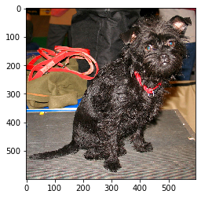

```
This is a dog: Wirehaired pointing griffon!
```

```python
def run_app(img_path):
    print('===== Input image =====')
    print(img_path)
    plt.imshow(cv2.cvtColor(cv2.imread(img_path), cv2.COLOR_BGR2RGB))
    plt.show()

    breed = predict_breed_transfer(img_path)

    if dog_detector(img_path):
        print(f'This is a dog: {breed}!')
    elif face_detector(img_path):
        print('This is a human!')
        print(f'And this human resembles a(n) {breed}!')
    else:
        print('This is neither a dog nor a person!')
        print(f'But it looks like a(n) {breed}')
    print()

run_app('dogImages/train/001.Affenpinscher/Affenpinscher_00014.jpg')
```

## Step 6: Test Your Algorithm

In this section, you will take your new algorithm for a spin! What kind of dog does the algorithm think that *you* look like? If you have a dog, does it predict your dog's breed accurately? If you have a cat, does it mistakenly think that your cat is a dog?

### (IMPLEMENTATION) Test Your Algorithm on Sample Images!

Test your algorithm at least six images on your computer. Feel free to use any images you like. Use at least two human and two dog images.

**Question 6:** Is the output better than you expected :) ? Or worse :( ? Provide at least three possible points of improvement for your algorithm.

**Answer:** (Three possible points for improvement)

Actually, the results for the images I used for testing are not very good. Whereas it detects with a good accuracy human faces (9 out of 10), it fails to detect the breed of the dogs I tested (only 2 out of 10 were corrently identified). But it is probably just a subset with low accuracy, since the entire test set was classified with 87% accuracy.

The following points could improve the results:

- A model specifically designed for dog detection could be used to detected if there is a dog in the image;
- A bigger dog dataset could be used to train the net; and
- Training the VGG16 architecture from scratch (same layers, but random weights), given that a much bigger dataset is available.

```
===== Input image =====
lfw\Aaron_Eckhart\Aaron_Eckhart_0001.jpg
```

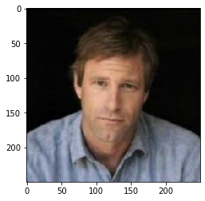

```
This is a human!
And this human resembles a(n) Irish wolfhound!

===== Input image =====
lfw\Aaron_Guiel\Aaron_Guiel_0001.jpg
```

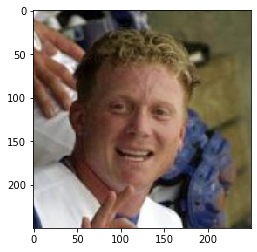

```
This is a human!
And this human resembles a(n) Irish wolfhound!

===== Input image =====
lfw\Aaron_Patterson\Aaron_Patterson_0001.jpg
```

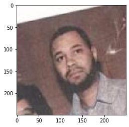

```
This is neither a dog nor a person!
But it looks like a(n) Japanese chin

===== Input image =====
lfw\Aaron_Peirsol\Aaron_Peirsol_0001.jpg
```

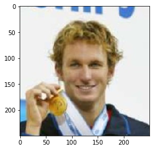

```
This is a human!
And this human resembles a(n) Australian shepherd!

===== Input image =====
lfw\Aaron_Peirsol\Aaron_Peirsol_0002.jpg
```

[figure not shown]

```
This is a human!
And this human resembles a(n) American water spaniel!

===== Input image =====
lfw\Aaron_Peirsol\Aaron_Peirsol_0003.jpg
```

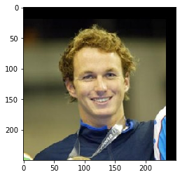

```
This is a human!
And this human resembles a(n) Australian shepherd!

===== Input image =====
lfw\Aaron_Peirsol\Aaron_Peirsol_0004.jpg
```

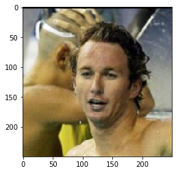

```
This is a human!
And this human resembles a(n) Chinese shar-pei!

===== Input image =====
lfw\Aaron_Pena\Aaron_Pena_0001.jpg
```

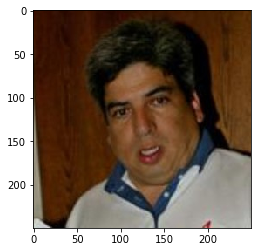

```
This is a human!
And this human resembles a(n) Afghan hound!

===== Input image =====
lfw\Aaron_Sorkin\Aaron_Sorkin_0001.jpg
```

[figure not shown]

```
This is a human!
And this human resembles a(n) Wirehaired pointing griffon!

===== Input image =====
lfw\Aaron_Sorkin\Aaron_Sorkin_0002.jpg
```

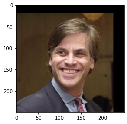

```
This is a human!
And this human resembles a(n) Irish wolfhound!

===== Input image =====
dogImages\test\001.Affenpinscher\Affenpinscher_00003.jpg
```

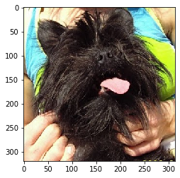

```
This is a dog: Cairn terrier!

===== Input image =====
dogImages\test\001.Affenpinscher\Affenpinscher_00023.jpg
```

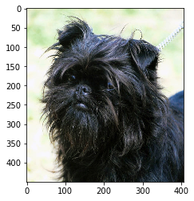

```
This is a dog: Cairn terrier!

===== Input image =====
dogImages\test\001.Affenpinscher\Affenpinscher_00036.jpg
```

[8 more figures not shown]

```
This is a dog: Irish wolfhound!
```

```python
for file in np.hstack((human_files[:10], dog_files[:10])):
    run_app(file)
```